# P6

Irsyad Parama Dwiputra

2024-10-01

```r
library(ggplot2)
library(tsibble)
library(tseries)
library(MASS)
library(forecast)
library(TSA)
library(TTR)
library(aTSA)
library(graphics)
library(readxl)
```

#**Input Data**

```r
data <- read_xlsx("C:/Users/Irsyad Parama/Downloads/DATA MPDW.xlsx", sheet = "201-300")
start_date <- as.Date("20-07-2023")
end_date <- as.Date("27-10-2023")
dates <- seq.Date(from = start_date, to = end_date, by = "day")

dates <- dates[1:101]

formatted_dates <- format(dates, "%d/%m/%Y")


data <- data.frame(dates = formatted_dates, value = data[1:101, 2])
head(data)
```

```
##        dates Tavg
## 1 20/07/0020 27.9
## 2 21/07/0020 28.8
## 3 22/07/0020 29.1
## 4 23/07/0020 29.0
## 5 24/07/0020 28.8
## 6 25/07/0020 28.0
```

```r
str(data)
```

```
## 'data.frame':    101 obs. of  2 variables:
##  $ dates: chr  "20/07/0020" "21/07/0020" "22/07/0020" "23/07/0020" ...
##  $ Tavg : num  27.9 28.8 29.1 29 28.8 28 28 29 28.9 28.6 ...
```

#**Eksplorasi Data**

```r
#Objek Time Series
data.ts <- ts(data$Tavg)
data.ts
```

```
## Time Series:
## Start = 1
## End = 101
## Frequency = 1
##   [1] 27.9 28.8 29.1 29.0 28.8 28.0 28.0 29.0 28.9 28.6 28.5 28.2 28.7 29.4 29.4
##  [16] 29.6 29.4 28.8 28.8 29.0 28.7 28.3 28.6 28.8 28.2 28.4 28.4 28.8 28.2 28.2
##  [31] 28.9 29.4 29.2 28.8 29.0 29.2 28.8 29.1 29.0 28.7 28.7 28.5 28.2 28.0 28.5
##  [46] 28.9 28.3 28.4 28.7 28.7 29.0 29.3 28.4 29.1 29.6 29.5 29.2 29.5 29.3 29.1
##  [61] 29.0 29.7 28.9 29.3 28.8 28.9 28.7 29.3 29.5 29.8 30.0 30.4 29.1 28.9 29.2
##  [76] 29.2 29.0 29.8 29.3 29.6 29.7 30.1 30.7 30.1 30.2 30.1 30.3 30.8 30.1 31.8
##  [91] 30.3 30.7 29.9 30.2 30.4 29.9 29.4 29.5 30.1 30.1   NA
```

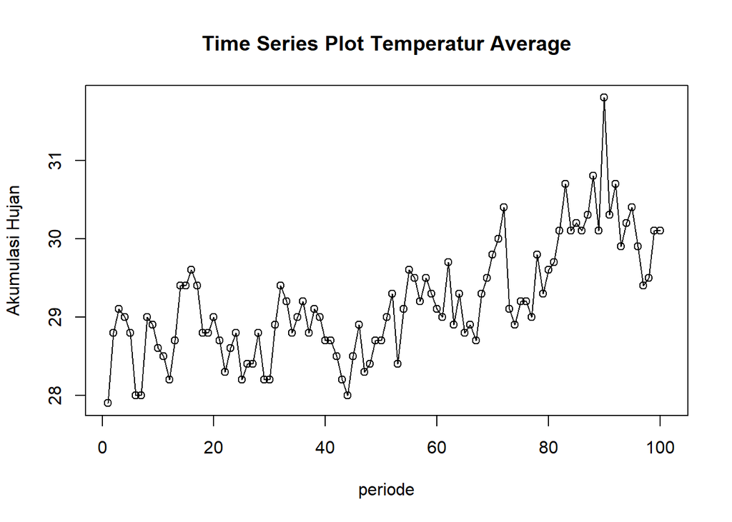

```r
#Plot Time Series
ts.plot(data.ts, xlab="periode", ylab="Akumulasi Hujan", main= "Time Series Plot Temperatur Average")
points(data.ts)
```

##**Plot Data Penuh**

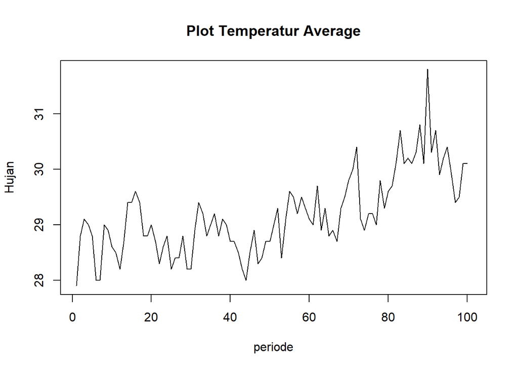

```r
plot.ts(data.ts, lty=1, xlab="periode", ylab="Hujan", main="Plot Temperatur Average")
```

Berdasarkan plot data deret waktu, terlihat bahwa data cenderung memiliki trend yang naik. Berdasarkan pola data, pembagian data latih dan data uji ditetapkan dengan proporsi 50:50.

##**Plot Data Latih**

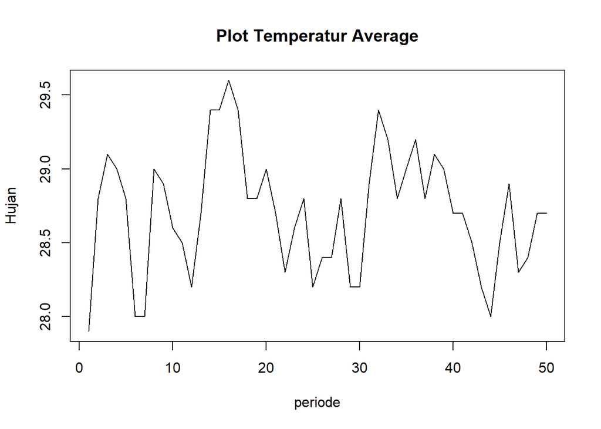

```r
datatrain <- data[1:50,]
train.ts <- ts(datatrain$Tavg)
plot.ts(train.ts, lty=1, xlab="periode", ylab="Hujan", main="Plot Temperatur Average")
```

Berdasarkan plot data deret waktu pada data latih, terlihat bahwa data tidak memiliki trend yang jelas. Dari pola ini, ada kemungkinan bahwa data bersifat stasioner dalam varian, artinya tidak ada perubahan signifikan dalam nilai rata-rata atau variabilitas data dari waktu ke waktu.

##**Plot Data Uji**

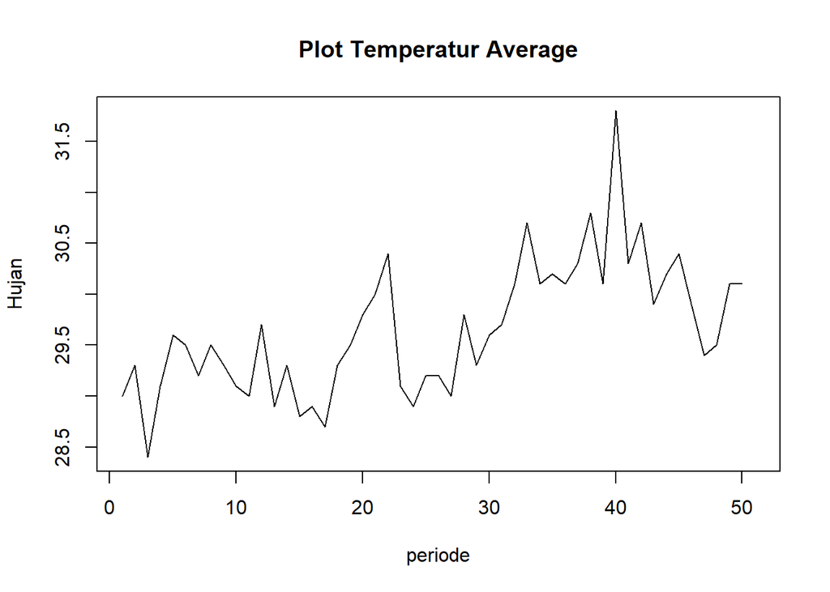

```r
datatest<-data[51:101,]
test.ts<-ts(datatest$Tavg)
plot.ts(test.ts, lty=1, xlab="periode", ylab="Hujan", main="Plot Temperatur Average")
```

#**Uji Stasioneritas Data**

##**Kestasioneran dalam Rataan**

###*Plot ACF*

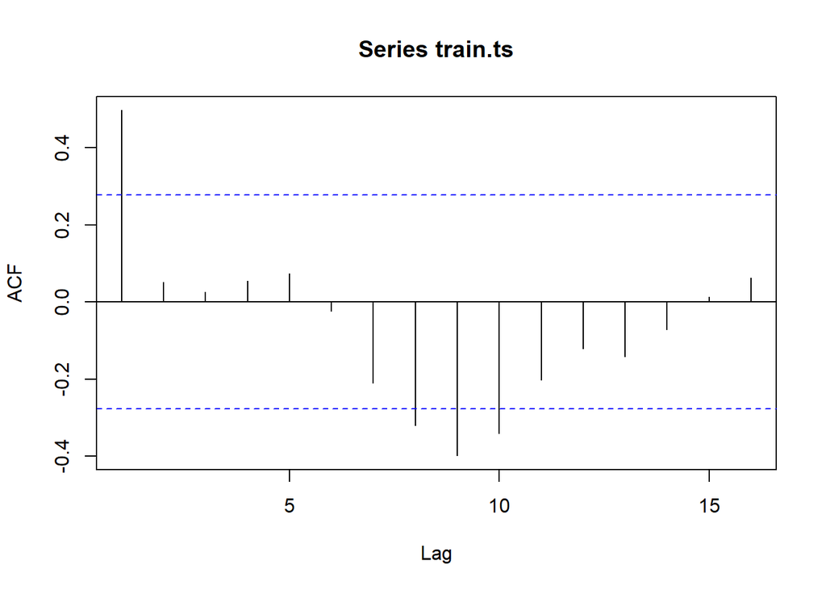

```r
acf(train.ts)
```

###*Uji ADF*

```r
tseries::adf.test(train.ts)
```

```
##
##  Augmented Dickey-Fuller Test
##
## data:  train.ts
## Dickey-Fuller = -2.7546, Lag order = 3, p-value = 0.2716
## alternative hypothesis: stationary
```

$H_0$ : Data tidak stasioner dalam rataan

$H_1$ : Data stasioner dalam rataan

##**Kestasioneran dalam Ragam**

```r
index <- seq(1:50)
bc = boxcox(train.ts~index, lambda = seq(-2,by=1))
```

[figure not shown]

```r
lambda <- bc$x[which.max(bc$y)]
lambda
```

```
## [1] 1
```

```r
#Selang Kepercayaan
bc$x[bc$y > max(bc$y) - 1/2 * qchisq(.95,1)]
```

```
##   [1] -2.00000000 -1.96969697 -1.93939394 -1.90909091 -1.87878788 -1.84848485
##   [7] -1.81818182 -1.78787879 -1.75757576 -1.72727273 -1.69696970 -1.66666667
##  [13] -1.63636364 -1.60606061 -1.57575758 -1.54545455 -1.51515152 -1.48484848
##  [19] -1.45454545 -1.42424242 -1.39393939 -1.36363636 -1.33333333 -1.30303030
##  [25] -1.27272727 -1.24242424 -1.21212121 -1.18181818 -1.15151515 -1.12121212
##  [31] -1.09090909 -1.06060606 -1.03030303 -1.00000000 -0.96969697 -0.93939394
##  [37] -0.90909091 -0.87878788 -0.84848485 -0.81818182 -0.78787879 -0.75757576
##  [43] -0.72727273 -0.69696970 -0.66666667 -0.63636364 -0.60606061 -0.57575758
##  [49] -0.54545455 -0.51515152 -0.48484848 -0.45454545 -0.42424242 -0.39393939
##  [55] -0.36363636 -0.33333333 -0.30303030 -0.27272727 -0.24242424 -0.21212121
##  [61] -0.18181818 -0.15151515 -0.12121212 -0.09090909 -0.06060606 -0.03030303
##  [67]  0.00000000  0.03030303  0.06060606  0.09090909  0.12121212  0.15151515
##  [73]  0.18181818  0.21212121  0.24242424  0.27272727  0.30303030  0.33333333
##  [79]  0.36363636  0.39393939  0.42424242  0.45454545  0.48484848  0.51515152
##  [85]  0.54545455  0.57575758  0.60606061  0.63636364  0.66666667  0.69696970
##  [91]  0.72727273  0.75757576  0.78787879  0.81818182  0.84848485  0.87878788
##  [97]  0.90909091  0.93939394  0.96969697  1.00000000
```

#**Penanganan (Diff) train.test**

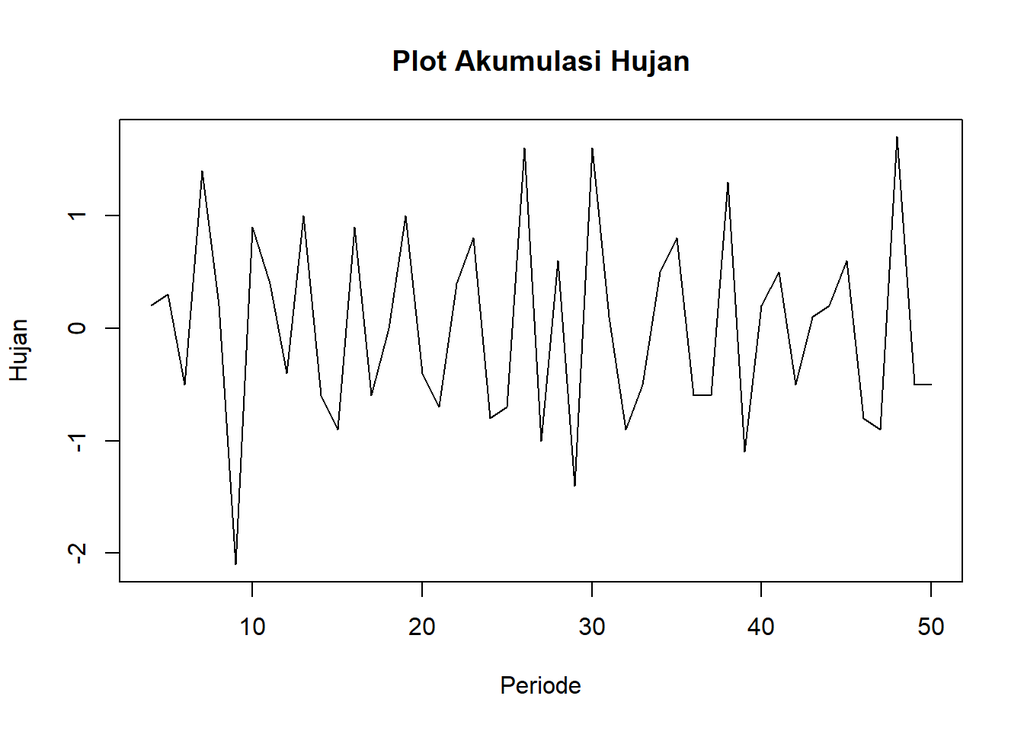

```r
train.diff<-diff(train.ts,differences = 3)
plot.ts(train.diff, lty=1, xlab="Periode", ylab="Hujan", main="Plot Akumulasi Hujan")
```

Berdasarkan plot data deret waktu, terlihat bahwa data sudah stasioner dalam rataan ditandai dengan data bergerak pada nilai rataan tertentu

```r
tseries::adf.test(train.diff)
```

```
##
##  Augmented Dickey-Fuller Test
##
## data:  train.diff
## Dickey-Fuller = -7.2462, Lag order = 3, p-value = 0.01
## alternative hypothesis: stationary
```

$H_0$: Data tidak stasioner dalam rataan

$H_0$ : Data stasioner dalam rataan

Berdasarkan uji ADF tersebut, didapat p-value sebesar 0.01 yang kurang dari taraf nyata 5%, maka tolak $H_0$ dan menandakan bahwa data stasioner dalam rataan.

```r
tr.diff.bc <- train.diff + abs(min(train.diff)) + 1
tr.diff.bc
```

```
## Time Series:
## Start = 4
## End = 50
## Frequency = 1
##  [1] 3.3 3.4 2.6 4.5 3.3 1.0 4.0 3.5 2.7 4.1 2.5 2.2 4.0 2.5 3.1 4.1 2.7 2.4 3.5
## [20] 3.9 2.3 2.4 4.7 2.1 3.7 1.7 4.7 3.2 2.2 2.6 3.6 3.9 2.5 2.5 4.4 2.0 3.3 3.6
## [39] 2.6 3.2 3.3 3.7 2.3 2.2 4.8 2.6 2.6
```

Ditambahkan konstanta sehingga nilainya positif semua agar bisa dilakukan boxcox

```r
index2 <- seq(1:47)
bc = boxcox(tr.diff.bc~index2, lambda = seq(-2,5,by=1))
```

[figure not shown]

```r
lambda <- bc$x[which.max(bc$y)]
lambda
```

```
## [1] 0.8282828
```

```r
#Selang kepercayaan
bc$x[bc$y > max(bc$y) - 1/2 * qchisq(.95,1)]
```

```
##  [1] 0.1212121 0.1919192 0.2626263 0.3333333 0.4040404 0.4747475 0.5454545
##  [8] 0.6161616 0.6868687 0.7575758 0.8282828 0.8989899 0.9696970 1.0404040
## [15] 1.1111111 1.1818182 1.2525253 1.3232323 1.3939394 1.4646465 1.5353535
## [22] 1.6060606 1.6767677
```

#**Spesifikasi Model**

```r
eacf(train.diff)
```

```
## AR/MA
##   0 1 2 3 4 5 6 7 8 9 10 11 12 13
## 0 x x o o o o o o o o o  o  o  o
## 1 x x o o o o o o o o o  o  o  o
## 2 x o o o o o o o o o o  o  o  o
## 3 x x o o o o o o o o o  o  o  o
## 4 x x o o o o o o o o o  o  o  o
## 5 x x o o o o o o o o o  o  o  o
## 6 x o o o o o o o o o o  o  o  o
## 7 x o o o o o o o o o o  o  o  o
```

Menggunakan plot EACF, dapat diambil beberapa model dengan melihat ujung segitiga yang terbentuk, antara lain ARIMA (0,0,2), ARIMA(1,0,3), ARIMA(2,0,4), ARIMA(0,0,3), ARIMA(0,0,4), ARIMA(3,0,5)

#**Model ARIMA(0,0,2)**

```r
model1.da=Arima(train.diff, order=c(0,0,2),method="ML")
summary(model1.da)
```

```
## Series: train.diff
## ARIMA(0,0,2) with non-zero mean
##
## Coefficients:
##           ma1     ma2   mean
##       -1.9922  1.0000  4e-04
## s.e.   0.0867  0.0866  6e-04
##
## sigma^2 = 0.1758:  log likelihood = -29.89
## AIC=67.78   AICc=68.73   BIC=75.18
##
## Training set error measures:
##                      ME      RMSE       MAE           MPE         MAPE
## Training set 0.07153035 0.4056823 0.3185885 -1.167618e+14 1.167618e+14
##                   MASE      ACF1
## Training set 0.2659723 0.1010502
```

```r
lmtest::coeftest(model1.da)
```

```
##
## z test of coefficients:
##
##              Estimate  Std. Error  z value Pr(>|z|)
## ma1       -1.99216327  0.08671643 -22.9733   <2e-16 ***
## ma2        0.99997983  0.08658897  11.5486   <2e-16 ***
## intercept  0.00036920  0.00062516   0.5906   0.5548
## ---
## Signif. codes:  0 '***' 0.001 '**' 0.01 '*' 0.05 '.' 0.1 ' ' 1
```

#**Model ARIMA(1,0,3)**

```r
model2.da=Arima(train.diff, order=c(1,0,3),method="ML")
summary(model2.da)
```

```
## Series: train.diff
## ARIMA(1,0,3) with non-zero mean
##
## Coefficients:
##           ar1      ma1      ma2     ma3   mean
##       -0.4223  -1.2791  -0.4186  0.7123  4e-04
## s.e.   0.2232   0.1714   0.2992  0.1611  7e-04
##
## sigma^2 = 0.1695:  log likelihood = -27.62
## AIC=67.25   AICc=69.35   BIC=78.35
##
## Training set error measures:
##                      ME      RMSE       MAE           MPE         MAPE
## Training set 0.06482931 0.3892139 0.3137942 -8.749148e+13 8.749148e+13
##                   MASE        ACF1
## Training set 0.2619698 -0.07678031
```

```r
lmtest::coeftest(model2.da)
```

```
##
## z test of coefficients:
##
##              Estimate  Std. Error z value  Pr(>|z|)
## ar1       -0.42225865  0.22318376 -1.8920   0.05849 .
## ma1       -1.27910887  0.17137940 -7.4636 8.418e-14 ***
## ma2       -0.41857672  0.29921531 -1.3989   0.16184
## ma3        0.71232464  0.16105860  4.4228 9.744e-06 ***
## intercept  0.00040602  0.00072385  0.5609   0.57485
## ---
## Signif. codes:  0 '***' 0.001 '**' 0.01 '*' 0.05 '.' 0.1 ' ' 1
```

#**Model ARIMA(0,0,4)**

```r
model3.da=Arima(train.diff, order=c(0,0,4),method="ML")
summary(model3.da)
```

```
## Series: train.diff
## ARIMA(0,0,4) with non-zero mean
##
## Coefficients:
##           ma1     ma2     ma3      ma4   mean
##       -2.0038  0.5359  0.9542  -0.4835  2e-04
## s.e.   0.2178  0.3123  0.2639   0.1721  4e-04
##
## sigma^2 = 0.1398:  log likelihood = -25.09
## AIC=62.17   AICc=64.27   BIC=73.27
##
## Training set error measures:
##                      ME      RMSE       MAE           MPE         MAPE
## Training set 0.06155566 0.3535135 0.2813201 -9.823866e+13 9.823866e+13
##                   MASE       ACF1
## Training set 0.2348589 0.07000995
```

```r
lmtest::coeftest(model3.da)
```

```
##
## z test of coefficients:
##
##              Estimate  Std. Error z value  Pr(>|z|)
## ma1       -2.00378334  0.21780981 -9.1997 < 2.2e-16 ***
## ma2        0.53590732  0.31231911  1.7159 0.0861810 .
## ma3        0.95424726  0.26393664  3.6154 0.0002998 ***
## ma4       -0.48345096  0.17214260 -2.8084 0.0049783 **
## intercept  0.00019748  0.00037985  0.5199 0.6031489
## ---
## Signif. codes:  0 '***' 0.001 '**' 0.01 '*' 0.05 '.' 0.1 ' ' 1
```

#**Model ARIMA(3,0,5)**

```r
model4.da=Arima(train.diff, order=c(3,0,5),method="ML")
summary(model4.da)
```

```
## Series: train.diff
## ARIMA(3,0,5) with non-zero mean
##
## Coefficients:
##           ar1     ar2     ar3      ma1      ma2     ma3     ma4      ma5   mean
##       -0.6871  0.2022  0.1801  -1.3413  -1.1641  1.6545  0.5849  -0.7339  2e-04
## s.e.   0.2892  0.2946  0.4125   0.3332   0.5992  0.6950  0.5000   0.2711  3e-04
##
## sigma^2 = 0.1349:  log likelihood = -24.11
## AIC=68.22   AICc=74.33   BIC=86.72
##
## Training set error measures:
##                      ME      RMSE       MAE          MPE        MAPE      MASE
## Training set 0.06489158 0.3301953 0.2557719 -7.98342e+13 7.98342e+13 0.2135301
##                     ACF1
## Training set 0.006954181
```

```r
lmtest::coeftest(model4.da)
```

```
##
## z test of coefficients:
##
##              Estimate  Std. Error z value  Pr(>|z|)
## ar1       -0.68713920  0.28917490 -2.3762  0.017492 *
## ar2        0.20222924  0.29461925  0.6864  0.492455
## ar3        0.18013214  0.41247686  0.4367  0.662323
## ma1       -1.34128497  0.33323982 -4.0250 5.698e-05 ***
## ma2       -1.16411594  0.59923136 -1.9427  0.052055 .
## ma3        1.65453422  0.69502567  2.3805  0.017287 *
## ma4        0.58494123  0.50003665  1.1698  0.242083
## ma5       -0.73386784  0.27105683 -2.7074  0.006781 **
## intercept  0.00015580  0.00029349  0.5308  0.595527
## ---
## Signif. codes:  0 '***' 0.001 '**' 0.01 '*' 0.05 '.' 0.1 ' ' 1
```

#**Kesimpulan**

Berdasarkan pendugaan parameter di atas **Model ARIMA(0,0,4)** merupakan model dengan **AIC** paling kecil **62.17**